# Part II - Loan Data Analysis Presentation

## by Isaac

## Investigation Overview

The major goals of this project are to investigate the numerous factors that influence borrower behavior and to gain insight into the interactions between various variables via the use of data visualizations and summary statistics.e.g state, employement status, monthly income. Key insights that i focused on was to know how are the loan borrowers are distributed amongst the state and if the populate affects the outcome. Also to know why are borrower borrowing loans since it can show the state of people in a country.

## Dataset Overview

The dataset used for this presentation is the Prosper Loan Dataset, which is America’s lending platform. his data set contains 113,937 loans with 81 variables on each loan, including loan amount, borrower rate (or interest rate), current loan status, borrower income, borrower employment status, borrower credit history, payment information and other.

## Top 5 states with most and least number of borrowers

- The state of CA, is the state with the most number of borrowers, and CA, TX and NY are the top 3 states with the most number of borrowers. The state of ND is the state with the least number of borrowers, and WY, ME and ND are the 3 states with the least number of borrowers.
- Most of the borrowers in CA state are employed depicting that this can be a catalyst for taking a loan

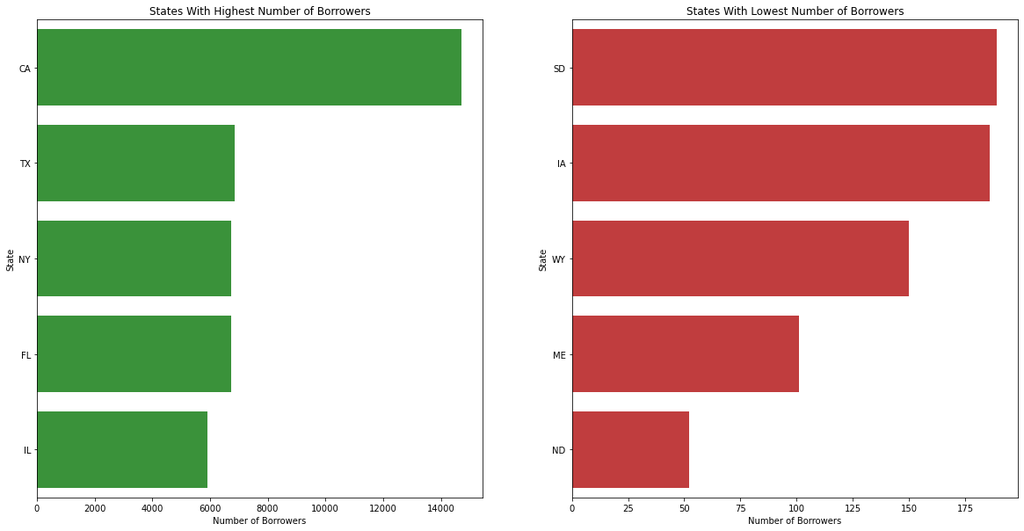

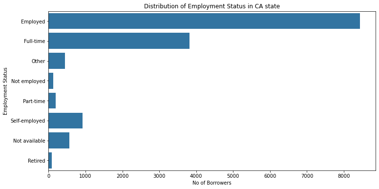

## Distribution of Monthly income

- The distribution of stated monthly income is severely right screwed, with most of stated monthly income less than 30k.

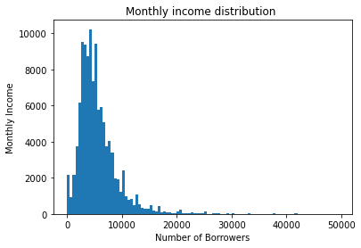

## Prosper Scores based on Monthly income

- It can be observed that there is Strong Positive Correlation between Monthly Income and Prosper Score. The Higher the Monthly Income, Higher the Prosper Score.

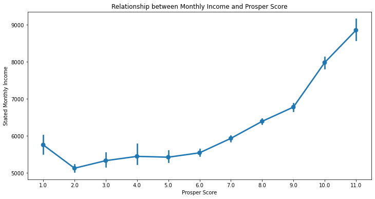

## Employment Status Distribution

- Most of the borrowers are Employed, with some of the borrowers being listed as Not Available and Other, whereas only a few of the borrowers were Not Employed.Also, some small number of the borrowers are also Retired.

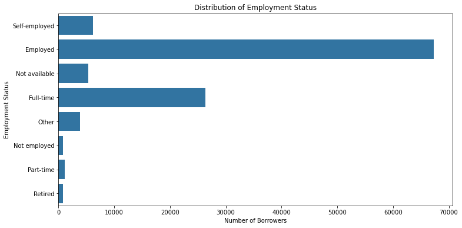